# Homework #6

Guang Yi Lim

4/16/2019

## Top dogs

In this homework, you will try to reproduce the fantastic infographic for [top dogs](https://informationisbeautiful.net/visualizations/best-in-show-whats-the-top-data-dog/), originally produced by David McCandless. The raw data can be found [here](https://docs.google.com/spreadsheets/d/1l_HfF5EaN-QgnLc2UYdCc7L2CVrk0p3VdGB1godOyhk/edit#gid=10). You can download this file by File – Download As – Microsoft Excel (.xlsx).

**Submission instructions**: Create a folder named `ds202_hw6`, and name the RMarkDown file including your solutions `hw6.Rmd` under this folder. For the submission, create a GitHub repository named `ds202_hw6` under your GitHub account, and push both `hw6.Rmd` and the knitted `hw6.html` before the deadline. I will assume you use the same GitHub username as for your HW5 submission. The latest version of your homework appearing on GitHub before the deadline is graded. *It is crucial to follow the exact folder structure and file names*, so that your homework can be reproduced and graded by an automated script. This homework is **due on April 25** before class.

1. Import the data and clean appropriately. To read in the data, you can use `readxl::read_xlsx('fileNameHere', sheet='sheetNameHere')`. Required data are in the sheets `Best in show` and `Best in show full sheet`. Take extra care on the column names and the first few rows of the data frame after read in.

```r
data <- read_excel("KIB - Best in Show (public).xlsx",sheet='Best in show full sheet')
```

```
## * `` -> ...2
## * `` -> ...4
## * `` -> ...5
## * `` -> ...9
## * `` -> ...10
## * … and 59 more problems
```

```r
#data <- data[-4]
#breed(1),type(3),size(31),score(5),popularity(6),intelligence(11),
dogs <- data %>% select(1,3,32,5,6,11)
dogs <-dogs[-(1:6),]
names(dogs)<-c("breed","type","size","score","popularity","intelligence")

dogs <- dogs %>% mutate_at(.funs = as.numeric, .vars = 4:6)
dogs$size <- as.factor(dogs$size)
dogs$size <- fct_rev(dogs$size)
dogs$type <- as.factor(dogs$type)
dogs %>% arrange(desc(intelligence))
```

```
## # A tibble: 171 x 6
##    breed        type         size   score popularity intelligence
##    <chr>        <fct>        <fct>  <dbl>      <dbl>        <dbl>
##  1 Afghan Hound hound        large   2.08         88           80
##  2 Basenji      hound        medium  2.51         93           79
##  3 Bulldog      non-sporting medium  0.99          6           78
##  4 Chow Chow    non-sporting medium  1.76         68           77
##  5 Borzoi       hound        large   1.89        102           76
##  6 Bloodhound   hound        large   1.66         48           75
##  7 Pekingese    toy          small   2.05         64           74
##  8 Beagle       hound        small   2.79          3           73
##  9 Mastiff      working      large   1.57         28           72
## 10 Basset Hound hound        small   2.54         41           71
## # … with 161 more rows
```

```r
dogs <- dogs %>% mutate (intelligence = ifelse(intelligence >=40,"clever","dumb"))
dogs$intelligence <- as.factor(dogs$intelligence)
str(dogs)
```

```
## Classes 'tbl_df', 'tbl' and 'data.frame':    171 obs. of  6 variables:
##  $ breed       : chr  "Cairn Terrier" "Welsh Springer Spaniel" "English Cocker Spaniel" "Cocker Spaniel" ...
##  $ type        : Factor w/ 7 levels "herding","hound",..: 5 4 4 4 6 1 1 7 3 6 ...
##  $ size        : Factor w/ 3 levels "small","medium",..: 1 2 2 1 1 2 1 2 1 1 ...
##  $ score       : num  3.53 3.34 3.33 3.3 3.26 3.25 3.22 3.22 3.21 3.2 ...
##  $ popularity  : num  59 130 63 27 38 60 20 16 62 139 ...
##  $ intelligence: Factor w/ 2 levels "clever","dumb": 2 2 2 2 2 2 2 1 1 2 ...
```

```r
dogsfinal <- na.omit(dogs)
str(dogsfinal)
```

```
## Classes 'tbl_df', 'tbl' and 'data.frame':    84 obs. of  6 variables:
##  $ breed       : chr  "Cairn Terrier" "Welsh Springer Spaniel" "English Cocker Spaniel" "Cocker Spaniel" ...
##  $ type        : Factor w/ 7 levels "herding","hound",..: 5 4 4 4 6 1 1 7 3 6 ...
##  $ size        : Factor w/ 3 levels "small","medium",..: 1 2 2 1 1 2 1 2 1 1 ...
##  $ score       : num  3.53 3.34 3.33 3.3 3.26 3.25 3.22 3.22 3.21 3.2 ...
##  $ popularity  : num  59 130 63 27 38 60 20 16 62 139 ...
##  $ intelligence: Factor w/ 2 levels "clever","dumb": 2 2 2 2 2 2 2 1 1 2 ...
##  - attr(*, "na.action")= 'omit' Named int  85 86 87 88 89 90 91 92 93 94 ...
##   ..- attr(*, "names")= chr  "85" "86" "87" "88" ...
```

2. Create a graphics similar to the [top dogs](https://informationisbeautiful.net/visualizations/best-in-show-whats-the-top-data-dog/) figure. Your figure need to display the following information with appropriate plotting elements:
- breed of dog
- type of dog (work, toy, etc.)
- size of dog
- data score
- popularity
- intelligence of the dog
- appropriate legends & explanation

Hints and Notes:

- The breed of dog can be displayed without the silhouttes (text only is fine)
- Avoid (too much) overlap!
- Choose a good color scheme.
- Your submission is supposed to be fully reproducible, i.e. the TA and I will ‘knit’ your submission in RStudio.

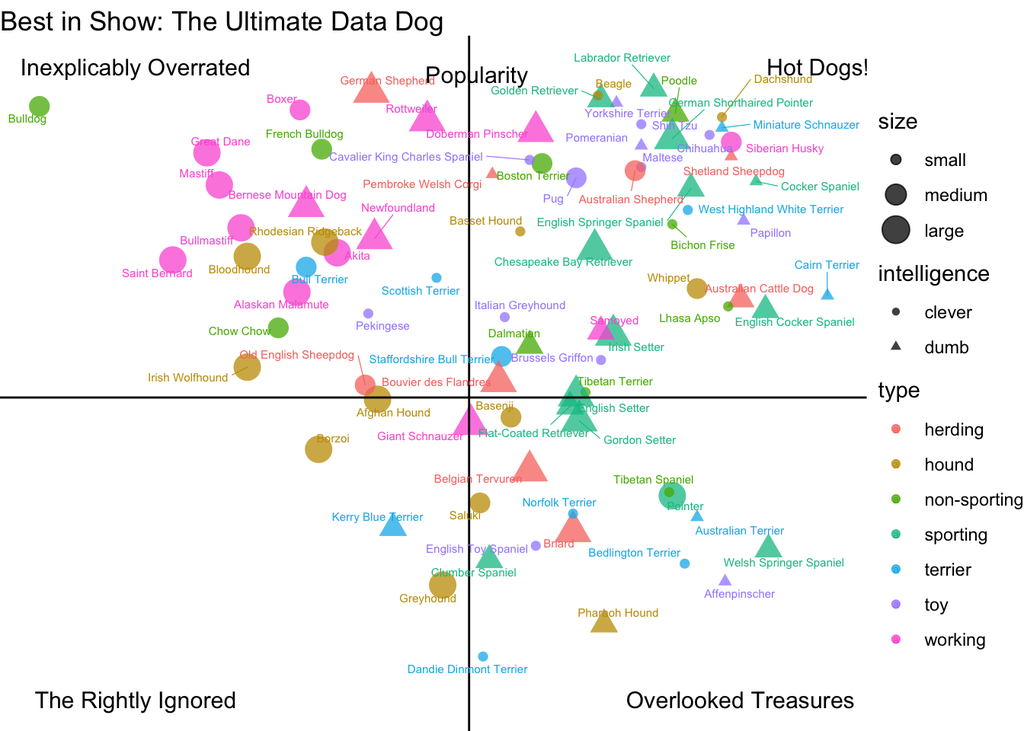

```r
p <-ggplot(dogsfinal,aes(x = score ,y = popularity,color = type,label = breed,shape = intelligence,size =size))+
      geom_point(alpha =.75)+scale_y_reverse()+ geom_vline(xintercept = 2.375) + geom_hline(yintercept = 87.5)
p<-p +guides(label = FALSE)+
  ggtitle("Best in Show: The Ultimate Data Dog") +
  theme(axis.text.x = element_blank(),axis.ticks.x = element_blank())+
  theme(axis.text.y = element_blank(),axis.ticks.y = element_blank()) +geom_text_repel(size=2,segment.size = 0.2)+
  theme_void()
p<- p+ annotate("text", label = "Inexplicably Overrated", x = 1.3, y = -5, size = 4)+
  annotate("text", label = "Hot Dogs!", x = 3.5, y = -5, size = 4) +
  annotate("text", label = "The Rightly Ignored", x = 1.3, y = 172, size = 4) +
  annotate("text", label = "Overlooked Treasures", x = 3.25, y = 172, size = 4) +
  annotate("text", label = "Popularity", x = 2.4, y = -3, size = 4)
p
```